# animint2 gallery

viz.link

repo.link

source.link

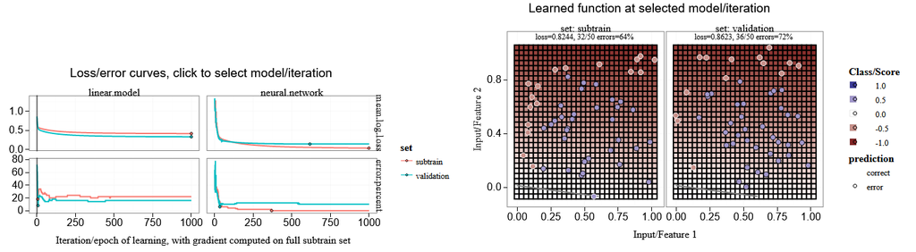

[Neural network vs linear model](https://github.com/nhintruong/Ch18-neural-networks-sim/tree/gh-pages)

[2024-06-11 15:33:47](https://github.com/tdhock/animint-book/blob/7e7a224c004843d42a6f7e6caa30e319bcdce901/Ch18-neural-networks-sim.R)

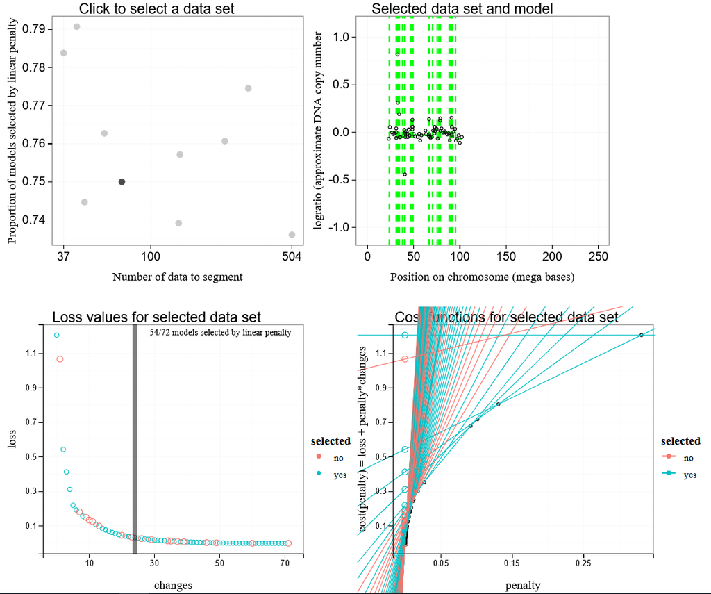

[Changepoint model selection](https://github.com/tdhock/2024-05-22-changepoint-model-selection/tree/gh-pages)

[2024-05-22 23:25:22](https://github.com/tdhock/changepoint-data-structure/blob/master/figure-loss-small-data.R)

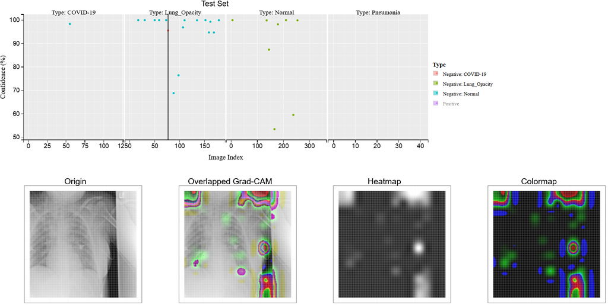

[Classifying chest X-rays, plot confidence](https://github.com/tdhock/Animated2GradCAM-COVID19-Chest-X-ray-ViT-V3-140px-609Case/tree/gh-pages)

[2024-04-09 22:39:37](https://github.com/TyBruceChen/Animinted2GradCAM?tab=readme-ov-file)

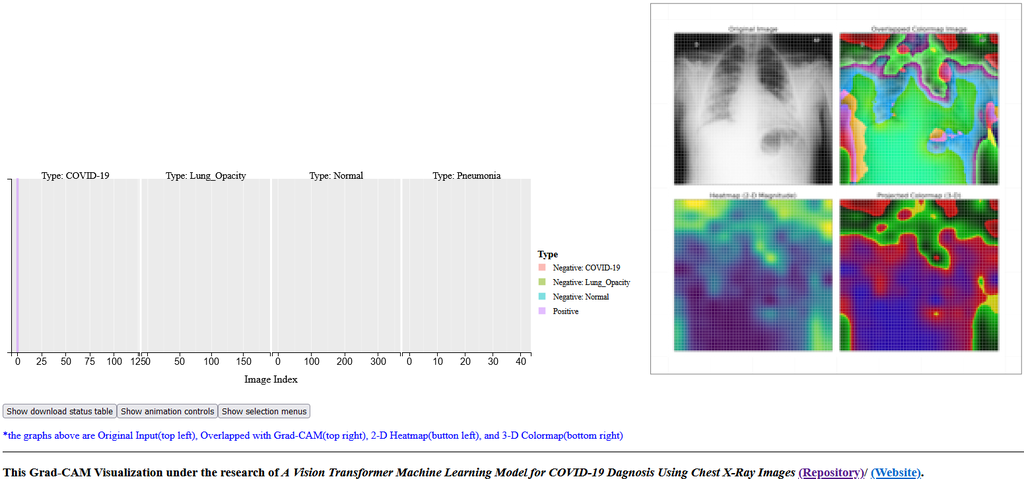

[Classifying Covid19 chest X-ray images](https://github.com/tdhock/Animated2GradCAM-COVID19-Chest-X-ray-ViT-V2-200px-696Case/tree/gh-pages)

[2024-04-09 16:38:46](https://github.com/TyBruceChen/Research-A-Fined-Tuned-ViT-for-COVID-19-Image-Auxiliary-Diagnosing)

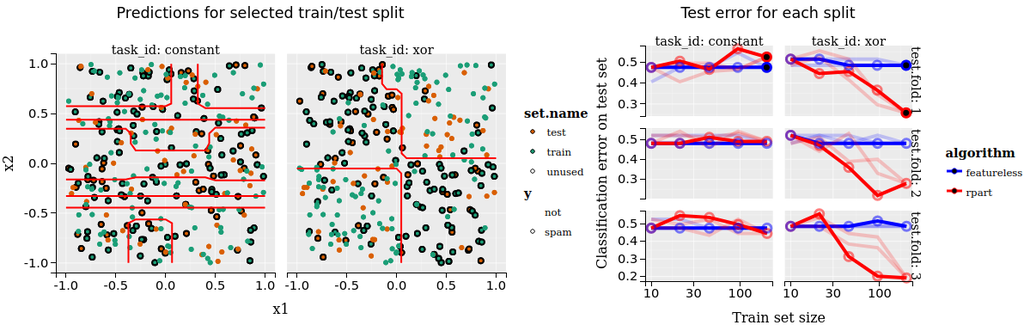

[Variable size train sets, classification](https://github.com/tdhock/2023-12-27-train-sizes-classification/tree/gh-pages)

[2023-12-28 05:37:38](https://github.com/tdhock/mlr3resampling/blob/main/vignettes/ResamplingVariableSizeTrainCV.Rmd)

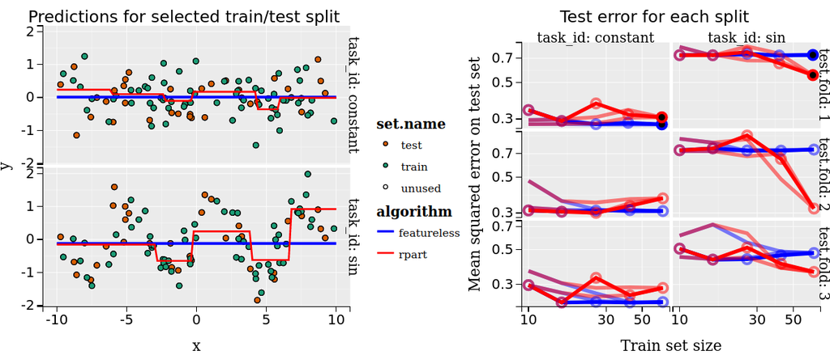

[Variable size train set, regression](https://github.com/tdhock/2023-12-26-train-sizes-regression/tree/gh-pages)

[2023-12-27 00:28:07](https://github.com/tdhock/mlr3resampling/blob/main/vignettes/Simulations.Rmd)

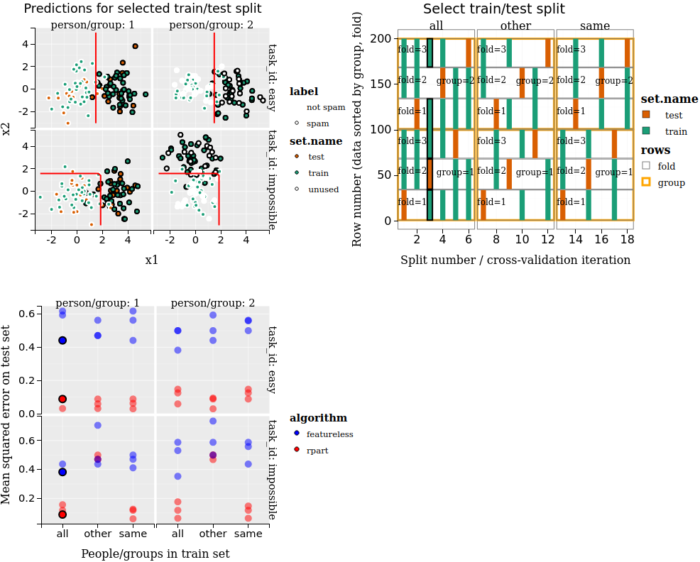

[Train/predict on subsets, classification](https://github.com/tdhock/2023-12-13-train-predict-subsets-classification/tree/gh-pages)

[2023-12-15 05:18:56](https://github.com/tdhock/mlr3resampling/blob/d7cbe06fdb562ff8c1c8b4ad0bc055b65bd7b2c6/vignettes/Simulations.Rmd)

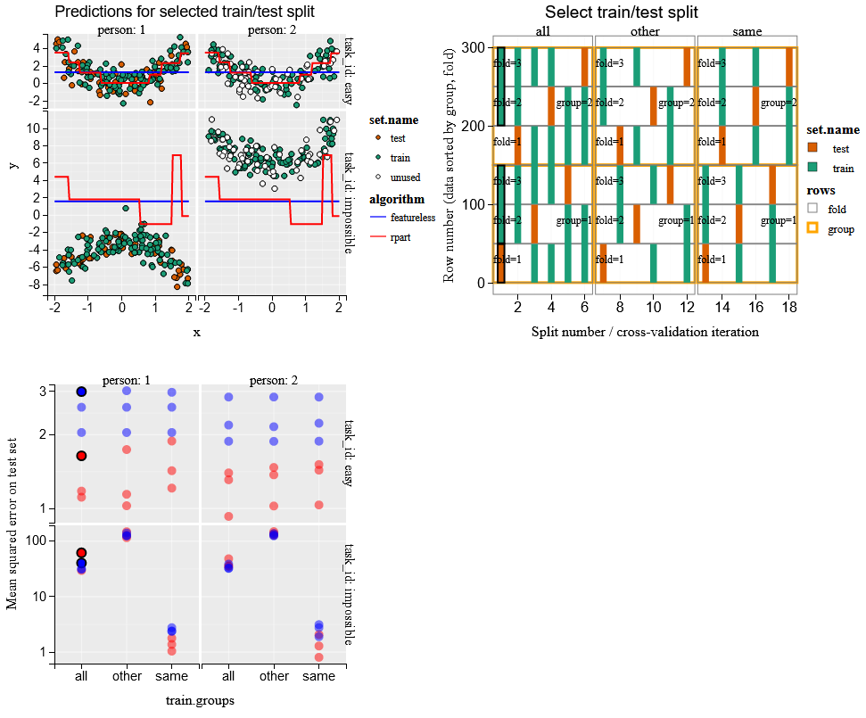

[Train/predict on subsets, regression](https://github.com/tdhock/2023-12-13-train-predict-subsets-regression/tree/gh-pages)

[2023-12-14 18:27:16](https://github.com/tdhock/mlr3resampling/blob/d7cbe06fdb562ff8c1c8b4ad0bc055b65bd7b2c6/vignettes/Simulations.Rmd)

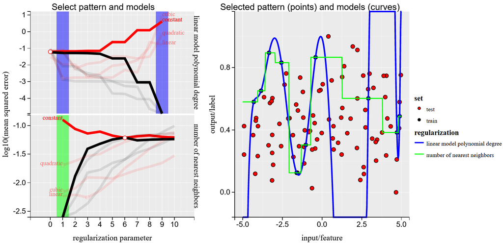

[Overfitting using linear model polynomial degree and nearest neighbors](https://github.com/tdhock/2023-12-04-degree-neighbors/tree/gh-pages)

[2023-12-04 20:53:37](https://github.com/tdhock/cs499-spring2020/blob/master/2020-02-03-capacity/figure-polynomial-neighbors-interactive.R)

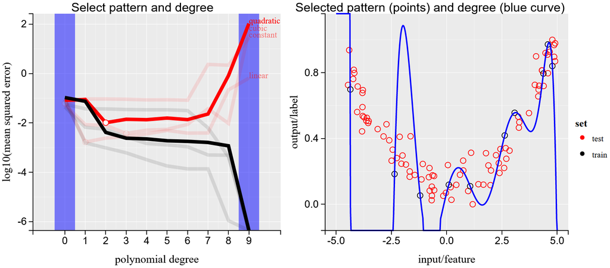

[Overfitting using linear model polynomial degree](https://github.com/tdhock/2023-12-04-capacity-polynomial-degree-several-patterns/tree/gh-pages)

[2023-12-04 19:19:43](https://github.com/tdhock/cs499-spring2020/blob/master/2020-02-03-capacity/figure-quadratic-interactive.R)

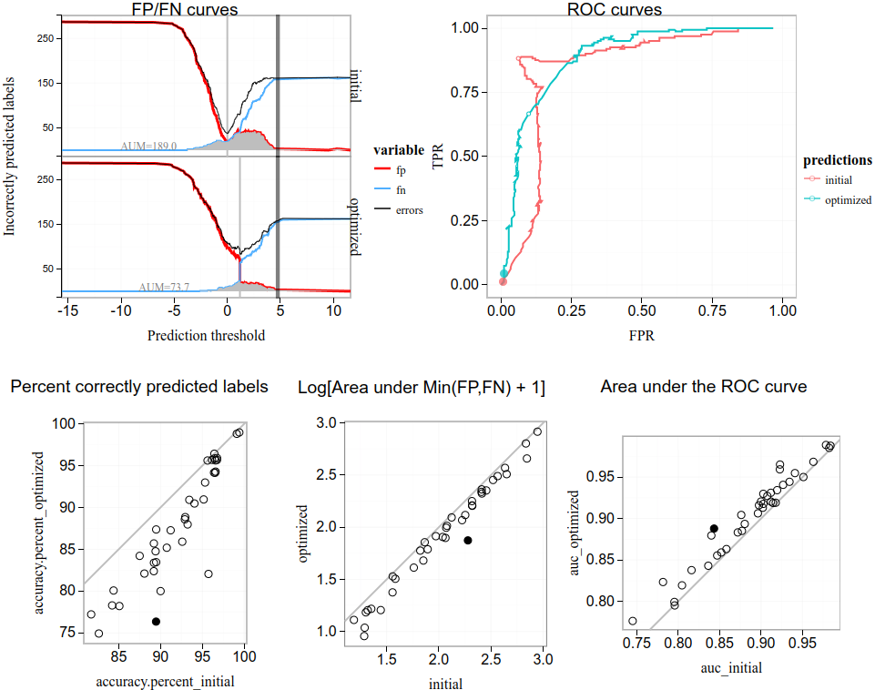

[Initial/optimized AUM/AUC for change-point problems](https://github.com/tdhock/2023-11-21-auc-improved/tree/gh-pages)

[2023-11-22 06:10:57](https://github.com/tdhock/max-generalized-auc/blob/master/figure-auc-improved-interactive.R)

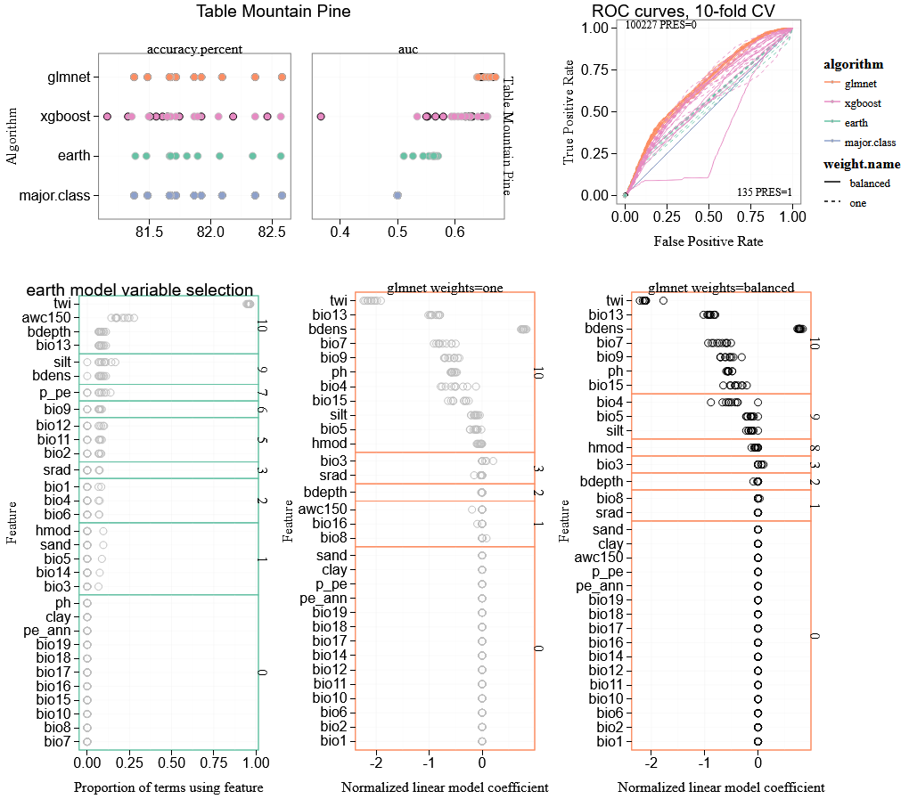

[Table Mountain Pine accuracy and variable selection](https://github.com/tdhock/2020-02-13-variable-importance-Table-Mountain-Pine/tree/gh-pages)

[2023-11-17 20:33:19](https://github.com/tdhock/species-variable-selection/blob/master/figure-batchtools-expired-earth.R)

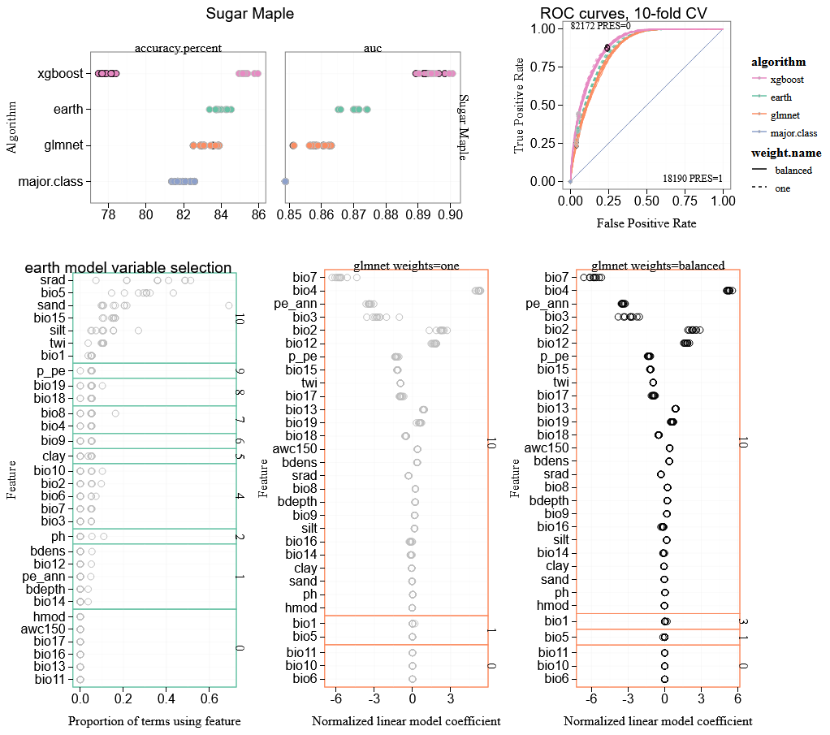

[Sugar Maple accuracy and variable selection](https://github.com/tdhock/2020-02-13-variable-importance-Sugar-Maple/tree/gh-pages)

[2023-11-17 20:33:16](https://github.com/tdhock/species-variable-selection/blob/master/figure-batchtools-expired-earth.R)

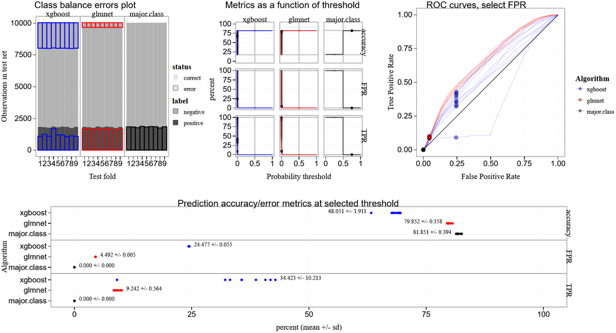

[Table Mountain Pine ROC curves and error/accuracy metrics](https://github.com/tdhock/2020-02-13-roc-vs-error-Table-Mountain-Pine/tree/gh-pages)

[2023-11-17 20:33:14](https://github.com/tdhock/species-variable-selection/blob/master/figure-batchtools-expired-earth.R)

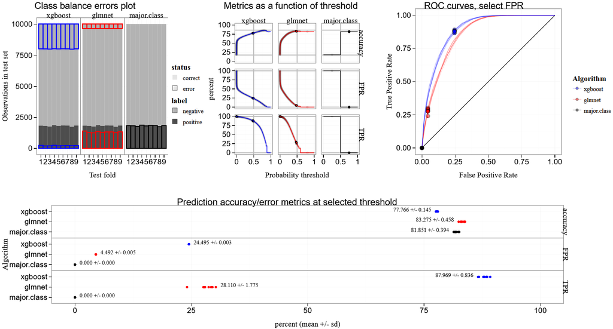

[Sugar Maple ROC curves and error/accuracy metrics](https://github.com/tdhock/2020-02-13-roc-vs-error-Sugar-Maple/tree/gh-pages)

[2023-11-17 20:33:12](https://github.com/tdhock/species-variable-selection/blob/master/figure-batchtools-expired-earth.R)

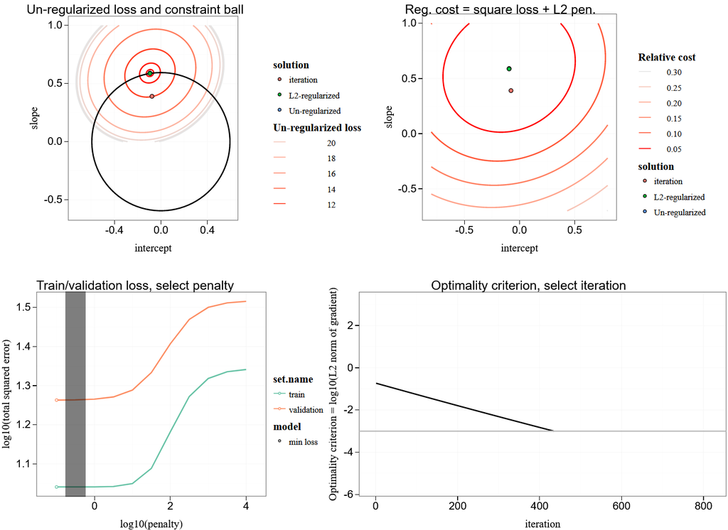

[L2-regularized (Ridge) least squares linear regression](https://github.com/tdhock/2019-02-14-L2-regularization/tree/gh-pages)

[2023-11-16 19:43:22](https://github.com/tdhock/cs499-spring2019/blob/master/2019-02-14-L2-regularization/viz.R)

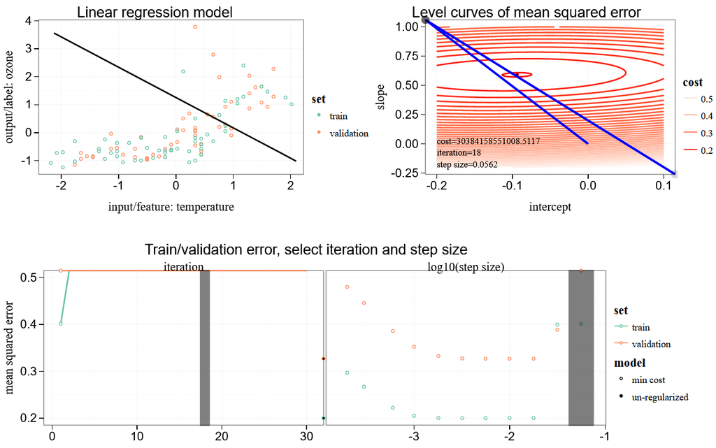

[Gradient descent with several step sizes for 1d linear regression in ozone data](https://github.com/tdhock/2019-02-05-linear-regression-1d-grad-desc-ozone-steps/tree/gh-pages)

[2023-11-16 19:36:32](https://github.com/tdhock/cs499-spring2019/blob/master/2019-02-05-linear-regression/viz.step.size.R)

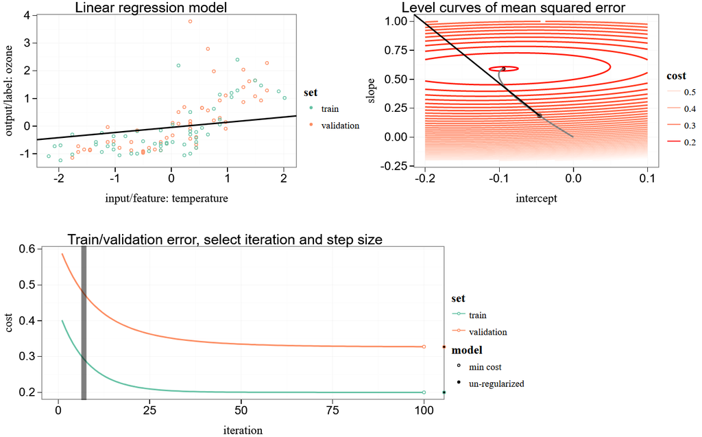

[Gradient descent for 1d linear regression in ozone data](https://github.com/tdhock/2019-02-05-linear-regression-1d-grad-desc-ozone/tree/gh-pages)

[2023-11-16 19:05:41](https://github.com/tdhock/cs499-spring2019/blob/master/2019-02-05-linear-regression/viz.R)

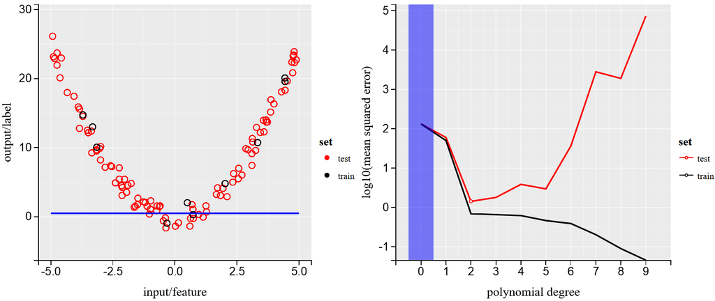

[Overfitting using linear model polynomial degree](https://github.com/tdhock/2020-02-03-capacity-polynomial-degree/tree/gh-pages)

[2023-11-16 18:36:26](https://github.com/tdhock/cs499-spring2020/blob/master/2020-02-03-capacity/figure-quadratic-interactive.R)

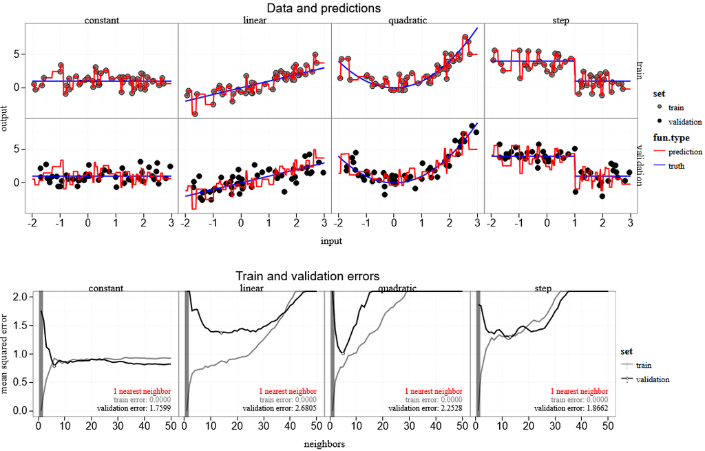

[Nearest neighbors algorithm for regression](https://github.com/tdhock/2019-01-nearest-neighbor-regression-one-split/tree/gh-pages)

[2023-11-15 23:51:55](https://github.com/tdhock/cs499-spring2019/blob/master/2019-01-17-nearest-neighbors/viz.R)

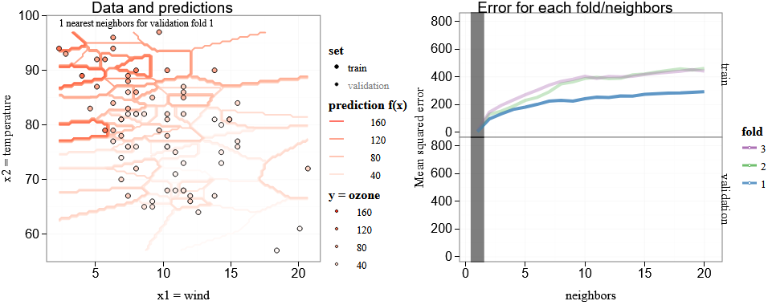

[Nearest neighbors for regression with 2D inputs](https://github.com/tdhock/2023-01-regression-2d/tree/gh-pages)

[2023-11-15 23:41:10](https://github.com/tdhock/cs499-spring2019/blob/master/2019-01-17-nearest-neighbors/viz-ozone-test.R)

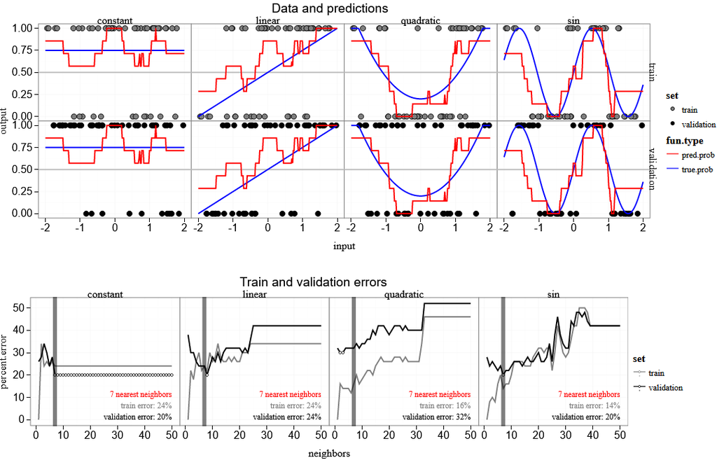

[Nearest neighbors algorithm for classification](https://github.com/tdhock/2019-01-nearest-neighbors-classification-1d/tree/gh-pages)

[2023-11-15 23:32:03](https://github.com/tdhock/cs499-spring2019/blob/master/2019-01-17-nearest-neighbors/viz-class-1d.R)

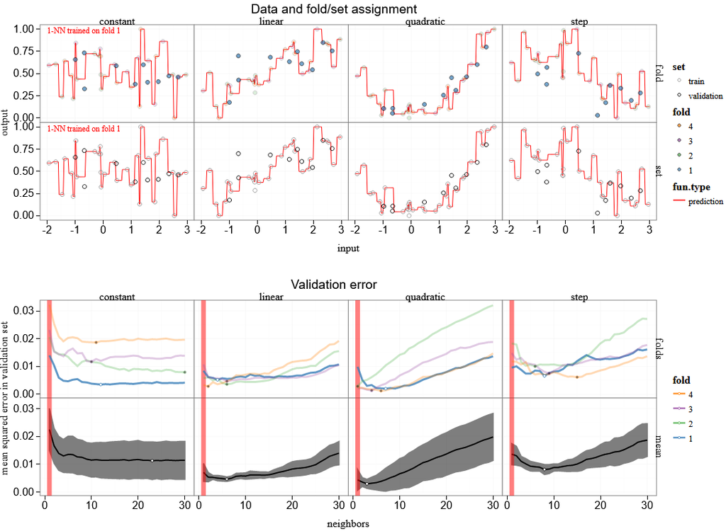

[4 fold cross-validation](https://github.com/tdhock/2019-01-nearest-neighbors-cross-validation/tree/gh-pages)

[2023-11-15 23:17:57](https://github.com/tdhock/cs499-spring2019/blob/master/2019-01-17-nearest-neighbors/viz-4folds.R)

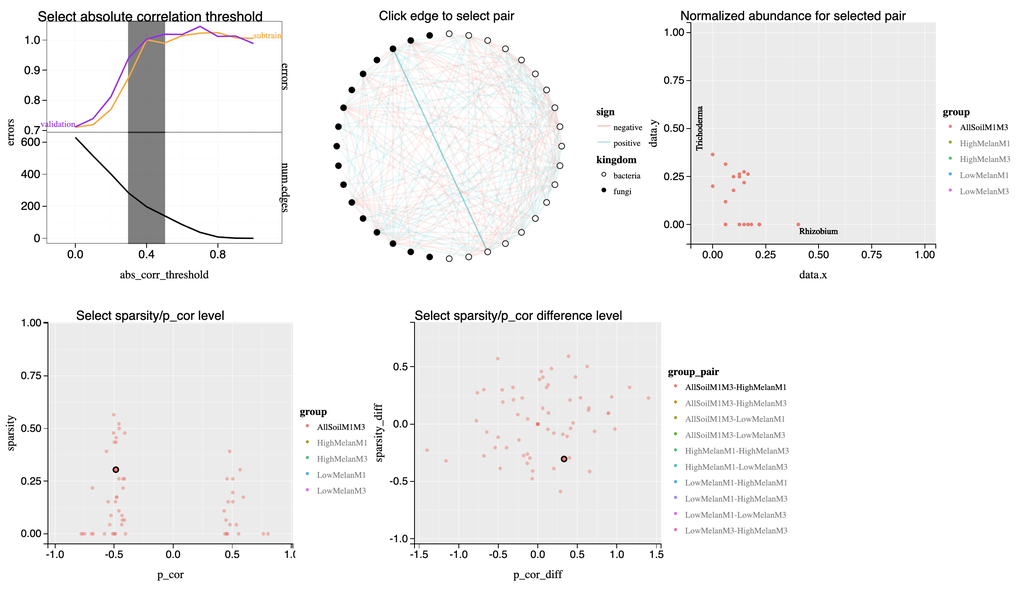

[bacteria_fungi_conservative visualization](https://github.com/EngineerDanny/EngineerDanny-necromass-figure-one-network/tree/gh-pages)

[2023-11-08 15:46:32](https://github.com/tdhock/necromass/blob/main/figure-one-network.Rmd)

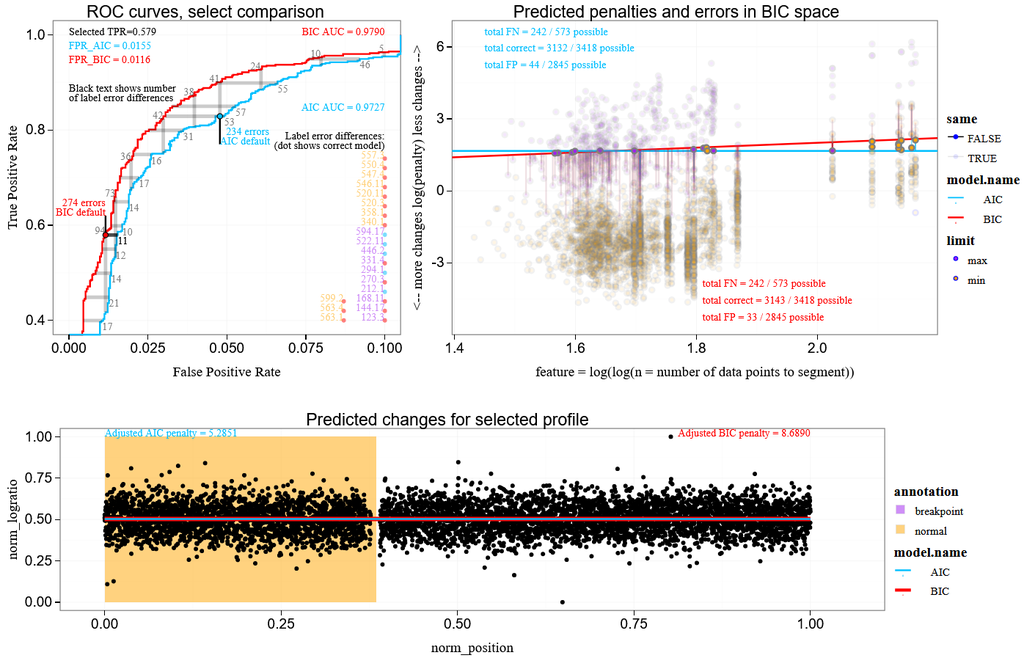

[AIC/BIC change-point detection comparison using ROC curves](https://github.com/tdhock/2023-11-interval-regression-differences/tree/gh-pages)

[2023-11-07 22:56:01](https://github.com/tdhock/change-tutorial/blob/master/figure-differences-interactive.R)

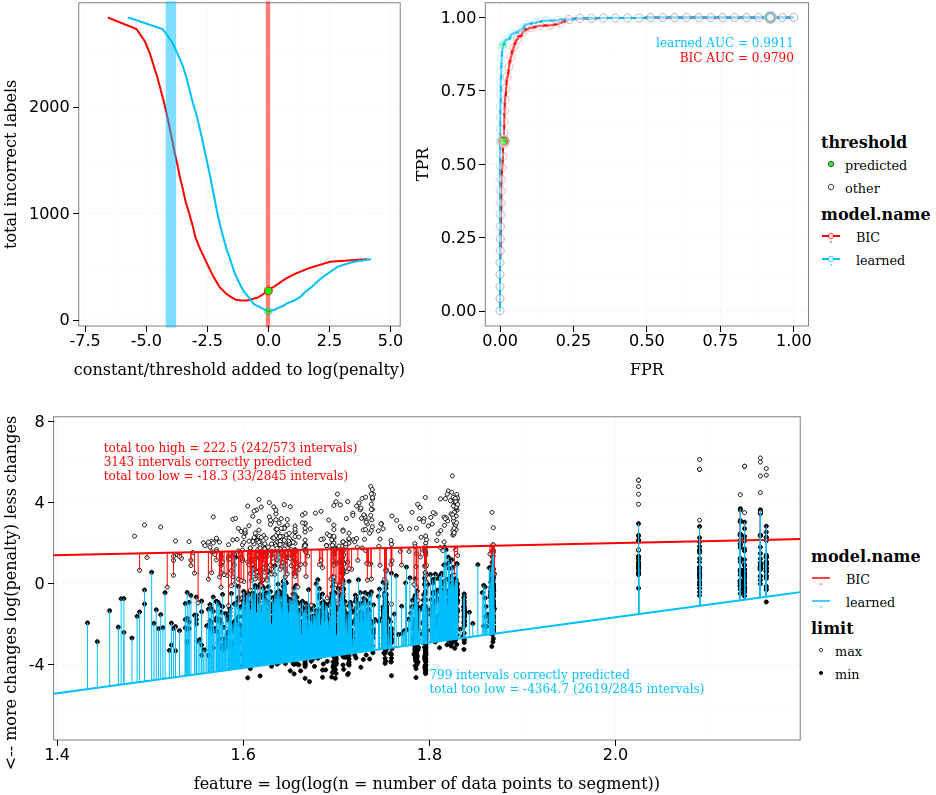

[BIC versus learned penalty in neuroblastoma data](https://github.com/tdhock/2023-08-interval-regression-BIC-vs-learned/tree/gh-pages)

[2023-11-05 06:21:24](https://github.com/tdhock/change-tutorial/blob/master/figure-regression-interactive.R)

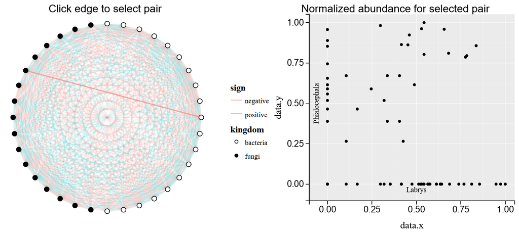

[bacteria_fungi_conservative visualization](https://github.com/tdhock/necromass-figure-one-network/tree/gh-pages)

[2023-10-27 23:58:42](https://github.com/tdhock/necromass/blob/main/figure-one-network.R)

Download this table: meta.csv

## Visualizations with missing meta-data

viz.link

repo.link

error

[tdhock/tdhock-figure-nnet-regression-degrees](https://tdhock.github.io/tdhock-figure-nnet-regression-degrees/)

[tdhock/tdhock-figure-nnet-regression-degrees](https://github.com/tdhock/tdhock-figure-nnet-regression-degrees/tree/gh-pages)

gh-pages branch of tdhock/tdhock-figure-nnet-regression-degrees should contain file named Capture.PNG (screenshot of data viz)

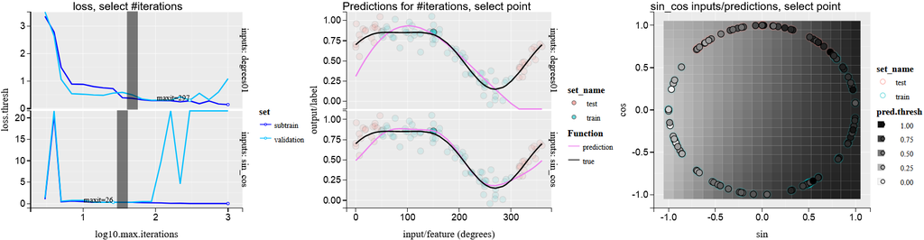

[tdhock/animint-figure-nnet-regression-degrees](https://github.com/tdhock/animint-figure-nnet-regression-degrees/tree/gh-pages)

plot.json file in gh-pages branch of tdhock/animint-figure-nnet-regression-degrees should have element named title which should be string describing the data viz

Download this table: error.csv

## Source code

- [This gallery repository](https://github.com/animint/gallery/tree/gh-pages),
- [`animint2::update_gallery()`](https://github.com/animint/animint2/blob/master/R/z_pages.R).